# Step 1 PERMA Profiler_SONA W1

Hayleigh

2025-16-10

## 0.1 Preliminary Steps

Load packages:

```r
library(dplyr)
library(tidyverse)
library(Hmisc)
library(psych)
library(ggplot2)
library(ggcorrplot)
library(reshape2)
```

Read in the data:

```r
#Hayleigh's Mac
df <- read.csv("/Volumes/Emotion Dynamics Lab/PEARS/Data/SEEDS/PEARS_SEEDS_Demographics___Daily_Surveys_SONA_W1/SEEDS SONA W1 Demographics ExpiWell Data Cleaned.csv", na.strings=c("","NA"))

# Jess's Mac
```

Subset the data to just the items from the PERMA Profiler and remove the rows that have question headers:

```r
perma_scale <- select(df [-c(1,2,3,4),], X.7, X.128:X.150)
head(perma_scale)
```

```
##                         X.7 X.128 X.129 X.130 X.131 X.132 X.133 X.134 X.135
## 5  6710308ccbc33a9b05332f10     5     5     5     9     7     8     4     1
## 6  67120e498f27e709d422380e     8    10     9    10    11     8     9    10
## 7  650627000f3cb6fde351cd3a     9     7     9    10     8     9     9     6
## 8  640e77934edf37206227baa5     7     8    10     8     9     9     8     8
## 9  6716a06183824766002149ed     6     4     4     8     8     7     5     7
## 10 6716db418382476600241ea1     8     8     9     4     6    10    10     5
##    X.136 X.137 X.138 X.139 X.140 X.141 X.142 X.143 X.144 X.145 X.146 X.147
## 5      5     6     8     7     7     1     7     4     1     7     7     5
## 6     10    10     3     4     9     5    11     7     4     9    11    11
## 7      8     9     8     7     8     5    11     7     9     8    11     8
## 8      9     8    10     8     7     8     9     9     9     9     8     8
## 9      6     4    10     6     5     5     6     9     4     8     6     3
## 10     8    10     5     8    10     6    11     4     7    10    11     6
##    X.148 X.149 X.150
## 5      8     8     8
## 6     11    10     9
## 7      9     9    10
## 8      8     9     8
## 9      5     4     5
## 10     9     7     9
```

Rename the items:

```r
colnames(perma_scale)[colnames(perma_scale)=="X.7"] <- "id"
colnames(perma_scale)[colnames(perma_scale)=="X.128"] <- "perma_1"
colnames(perma_scale)[colnames(perma_scale)=="X.129"] <- "perma_2"
colnames(perma_scale)[colnames(perma_scale)=="X.130"] <- "perma_3"
colnames(perma_scale)[colnames(perma_scale)=="X.131"] <- "perma_4"
colnames(perma_scale)[colnames(perma_scale)=="X.132"] <- "perma_5"
colnames(perma_scale)[colnames(perma_scale)=="X.133"] <- "perma_6"
colnames(perma_scale)[colnames(perma_scale)=="X.134"] <- "perma_7"
colnames(perma_scale)[colnames(perma_scale)=="X.135"] <- "perma_8"
colnames(perma_scale)[colnames(perma_scale)=="X.136"] <- "perma_9"
colnames(perma_scale)[colnames(perma_scale)=="X.137"] <- "perma_10"
colnames(perma_scale)[colnames(perma_scale)=="X.138"] <- "perma_11"
colnames(perma_scale)[colnames(perma_scale)=="X.139"] <- "perma_12"
colnames(perma_scale)[colnames(perma_scale)=="X.140"] <- "perma_13"
colnames(perma_scale)[colnames(perma_scale)=="X.141"] <- "perma_14"
colnames(perma_scale)[colnames(perma_scale)=="X.142"] <- "perma_15"
colnames(perma_scale)[colnames(perma_scale)=="X.143"] <- "perma_16"
colnames(perma_scale)[colnames(perma_scale)=="X.144"] <- "perma_17"
colnames(perma_scale)[colnames(perma_scale)=="X.145"] <- "perma_18"
colnames(perma_scale)[colnames(perma_scale)=="X.146"] <- "perma_19"
colnames(perma_scale)[colnames(perma_scale)=="X.147"] <- "perma_20"
colnames(perma_scale)[colnames(perma_scale)=="X.148"] <- "perma_21"
colnames(perma_scale)[colnames(perma_scale)=="X.149"] <- "perma_22"
colnames(perma_scale)[colnames(perma_scale)=="X.150"] <- "perma_23"
```

Convert the “prefer not to respond” options to “NA”:

```r
perma_scale[perma_scale == 11] <- NA
```

Variables are pulled in as factors and we want to make them numeric values:

```r
perma_scale[,paste0("perma_",1:23)] <- lapply(perma_scale[,paste0("perma_",1:23)], as.numeric)
str(perma_scale)
```

```
## 'data.frame':    296 obs. of  24 variables:
##  $ id      : chr  "6710308ccbc33a9b05332f10" "67120e498f27e709d422380e" "650627000f3cb6fde351cd3a" "640e77934edf37206227baa5" ...
##  $ perma_1 : num  5 8 9 7 6 8 8 8 5 6 ...
##  $ perma_2 : num  5 10 7 8 4 8 7 6 8 5 ...
##  $ perma_3 : num  5 9 9 10 4 9 6 9 6 7 ...
##  $ perma_4 : num  9 10 10 8 8 4 4 4 8 9 ...
##  $ perma_5 : num  7 NA 8 9 8 6 8 9 5 7 ...
##  $ perma_6 : num  8 8 9 9 7 10 7 8 8 9 ...
##  $ perma_7 : num  4 9 9 8 5 10 6 9 6 8 ...
##  $ perma_8 : num  1 10 6 8 7 5 7 6 9 10 ...
##  $ perma_9 : num  5 10 8 9 6 8 6 10 7 7 ...
##  $ perma_10: num  6 10 9 8 4 10 4 7 5 7 ...
##  $ perma_11: num  8 3 8 10 10 5 9 2 10 7 ...
##  $ perma_12: num  7 4 7 8 6 8 5 6 9 10 ...
##  $ perma_13: num  7 9 8 7 5 10 5 9 8 6 ...
##  $ perma_14: num  1 5 5 8 5 6 3 3 5 4 ...
##  $ perma_15: num  7 NA NA 9 6 NA 8 10 8 8 ...
##  $ perma_16: num  4 7 7 9 9 4 5 2 10 8 ...
##  $ perma_17: num  1 4 9 9 4 7 9 8 6 8 ...
##  $ perma_18: num  7 9 8 9 8 10 5 8 9 8 ...
##  $ perma_19: num  7 NA NA 8 6 NA 8 NA 7 5 ...
##  $ perma_20: num  5 NA 8 8 3 6 6 8 5 4 ...
##  $ perma_21: num  8 NA 9 8 5 9 8 NA 8 6 ...
##  $ perma_22: num  8 10 9 9 4 7 6 6 6 5 ...
##  $ perma_23: num  8 9 10 8 5 9 7 10 7 6 ...
```

Label the items:

```r
label(perma_scale[["perma_1"]]) <- "How much of the time do you feel you are making progress towards accomplishing your goals?"
label(perma_scale[["perma_2"]]) <- "How often do you become absorbed in what you are doing?"
label(perma_scale[["perma_3"]]) <- "In general, how often do you feel joyful?"
label(perma_scale[["perma_4"]]) <- "In general, how often do you feel anxious?"
label(perma_scale[["perma_5"]]) <- "How often do you achieve the important goals you have set for yourself?"
label(perma_scale[["perma_6"]]) <- "In general, how would you say your health is?"
label(perma_scale[["perma_7"]]) <- "In general, to what extent do you lead a purposeful and meaningful life?"
label(perma_scale[["perma_8"]]) <- "To what extent do you receive help and support from others when you need it?"
label(perma_scale[["perma_9"]]) <- "In general, to what extent do you feel that what you do in your life is valuable and worthwhile?"
label(perma_scale[["perma_10"]]) <- "In general, to what extent do you feel excited and interested in things?"
label(perma_scale[["perma_11"]]) <- "How lonely do you feel in your daily life?"
label(perma_scale[["perma_12"]]) <- "How satisfied are you with your current physical health?"
label(perma_scale[["perma_13"]]) <- "In general, how often do you feel positive?"
label(perma_scale[["perma_14"]]) <- "In general, how often do you feel angry?"
label(perma_scale[["perma_15"]]) <- "How often are you able to handle your responsibilities?"
label(perma_scale[["perma_16"]]) <- "In general, how often do you feel sad?"
label(perma_scale[["perma_17"]]) <- "How often do you lose track of time while doing something you enjoy?"
label(perma_scale[["perma_18"]]) <- "Compared to others of your same age and sex, how is your health?"
label(perma_scale[["perma_19"]]) <- "To what extent do you feel loved?"
label(perma_scale[["perma_20"]]) <- "To what extent do you generally feel you have a sense of direction in your life?"
label(perma_scale[["perma_21"]]) <- "How satisfied are you with your personal relationships?"
label(perma_scale[["perma_22"]]) <- "In general, to what extent do you feel contented?"
label(perma_scale[["perma_23"]]) <- "Taking all things together, how happy would you say you are?"

# Look at the data
head(perma_scale)
```

```
##                          id perma_1 perma_2 perma_3 perma_4 perma_5 perma_6
## 5  6710308ccbc33a9b05332f10       5       5       5       9       7       8
## 6  67120e498f27e709d422380e       8      10       9      10      NA       8
## 7  650627000f3cb6fde351cd3a       9       7       9      10       8       9
## 8  640e77934edf37206227baa5       7       8      10       8       9       9
## 9  6716a06183824766002149ed       6       4       4       8       8       7
## 10 6716db418382476600241ea1       8       8       9       4       6      10
##    perma_7 perma_8 perma_9 perma_10 perma_11 perma_12 perma_13 perma_14
## 5        4       1       5        6        8        7        7        1
## 6        9      10      10       10        3        4        9        5
## 7        9       6       8        9        8        7        8        5
## 8        8       8       9        8       10        8        7        8
## 9        5       7       6        4       10        6        5        5
## 10      10       5       8       10        5        8       10        6
##    perma_15 perma_16 perma_17 perma_18 perma_19 perma_20 perma_21 perma_22
## 5         7        4        1        7        7        5        8        8
## 6        NA        7        4        9       NA       NA       NA       10
## 7        NA        7        9        8       NA        8        9        9
## 8         9        9        9        9        8        8        8        9
## 9         6        9        4        8        6        3        5        4
## 10       NA        4        7       10       NA        6        9        7
##    perma_23
## 5         8
## 6         9
## 7        10
## 8         8
## 9         5
## 10        9
```

## 0.2 Calculate the scales

### 0.2.1 Calculate the standard mean and sum of subscales

Calculate the mean scores of PERMA Profiler and Subscales, in line with the instructions described in the [instruction manual](https://www.peggykern.org/uploads/5/6/6/7/56678211/the_PERMA-profiler_101416.pdf).

Positive Emotion subscale:

```r
perma_scale <- mutate (perma_scale, perma_positive_sum = perma_3 + perma_13 + perma_22)
perma_scale$perma_positive_mean <- apply(perma_scale[, c("perma_3", "perma_13", "perma_22")], 1, mean)

label(perma_scale[["perma_positive_sum"]]) <- "sum of PERMA positive emotion items"
label(perma_scale[["perma_positive_mean"]]) <- "mean of PERMA positive emotion items"
```

Engagement subscale:

```r
perma_scale <- mutate (perma_scale, perma_engagement_sum = perma_2 + perma_10 + perma_17)
perma_scale$perma_engagement_mean <- apply(perma_scale[, c("perma_2", "perma_10", "perma_17")], 1, mean)

label(perma_scale[["perma_engagement_sum"]]) <- "sum of PERMA engagement items"
label(perma_scale[["perma_engagement_mean"]]) <- "mean of PERMA engagement items"
```

Relationships subscale:

```r
perma_scale <- mutate (perma_scale, perma_relationships_sum = perma_8 + perma_19 + perma_21)
perma_scale$perma_relationships_mean <- apply(perma_scale[, c("perma_8", "perma_19", "perma_21")], 1, mean)

label(perma_scale[["perma_relationships_sum"]]) <- "sum of PERMA relationships items"
label(perma_scale[["perma_relationships_mean"]]) <- "mean of PERMA relationships items"
```

Meaning subscale:

```r
perma_scale <- mutate (perma_scale, perma_meaning_sum = perma_7 + perma_9 + perma_20)
perma_scale$perma_meaning_mean <- apply(perma_scale[, c("perma_7", "perma_9", "perma_20")], 1, mean)

label(perma_scale[["perma_meaning_sum"]]) <- "sum of PERMA meaning items"
label(perma_scale[["perma_meaning_mean"]]) <- "mean of PERMA meaning items"
```

Accomplishment subscale:

```r
perma_scale <- mutate (perma_scale, perma_accomplishment_sum = perma_1 + perma_5 + perma_15)
perma_scale$perma_accomplishment_mean <- apply(perma_scale[, c("perma_1", "perma_5", "perma_15")], 1, mean)

label(perma_scale[["perma_accomplishment_sum"]]) <- "sum of PERMA accomplishment items"
label(perma_scale[["perma_accomplishment_mean"]]) <- "mean of PERMA accomplishment items"
```

Overall well-being subscale:

```r
perma_scale <- mutate (perma_scale, perma_wellbeing_sum = perma_3 + perma_13 + perma_22 + perma_2 + perma_10 + perma_17 + perma_8 + perma_19 + perma_21 + perma_7 + perma_9 + perma_20 + perma_1 + perma_5 + perma_15 + perma_23)
perma_scale$perma_wellbeing_mean <- apply(perma_scale[, c("perma_3", "perma_13", "perma_22", "perma_2", "perma_10", "perma_17", "perma_8", "perma_19", "perma_21", "perma_7", "perma_9", "perma_20", "perma_1", "perma_5", "perma_15", "perma_23")], 1, mean)

label(perma_scale[["perma_wellbeing_sum"]]) <- "sum of PERMA overall wellbeing items"
label(perma_scale[["perma_wellbeing_mean"]]) <- "mean of PERMA overall wellbeing items"
```

Negative Emotion subscale:

```r
perma_scale <- mutate (perma_scale, perma_negative_sum = perma_4 + perma_14 + perma_16)
perma_scale$perma_negative_mean <- apply(perma_scale[, c("perma_4", "perma_14", "perma_16")], 1, mean)

label(perma_scale[["perma_negative_sum"]]) <- "sum of PERMA negative emotion items"
label(perma_scale[["perma_negative_mean"]]) <- "mean of PERMA negative emotion items"
```

Health subscale:

```r
perma_scale <- mutate (perma_scale, perma_health_sum = perma_6 + perma_12 + perma_18)
perma_scale$perma_health_mean <- apply(perma_scale[, c("perma_6", "perma_12", "perma_18")], 1, mean)

label(perma_scale[["perma_health_sum"]]) <- "sum of PERMA health items"
label(perma_scale[["perma_health_mean"]]) <- "mean of PERMA health items"
```

Loneliness subscale (single item):

```r
perma_scale <- mutate (perma_scale, perma_loneliness_sum = perma_11)
perma_scale$perma_loneliness_mean <- perma_scale[, c("perma_11")]

label(perma_scale[["perma_loneliness_sum"]]) <- "sum of PERMA loneliness items"
label(perma_scale[["perma_loneliness_mean"]]) <- "mean of PERMA loneliness items"
```

Save the data file:

```r
# Write to Hayleigh's Mac:
write.csv(perma_scale,'/Volumes/Emotion Dynamics Lab/PEARS/Data/SEEDS/PEARS_SEEDS_Demographics___Daily_Surveys_SONA_W1/PERMA Profiler-Step1_SONA_W1.csv')

# Jess's Mac
```

## 0.3 Reliability of subscales and the total scale

Reliability of positive emotions

```r
positive <- subset(perma_scale, select = c("perma_3","perma_13","perma_22"))
psych::alpha(positive)
```

```
## Number of categories should be increased  in order to count frequencies.
```

```
##
## Reliability analysis
## Call: psych::alpha(x = positive)
##
##   raw_alpha std.alpha G6(smc) average_r S/N   ase mean  sd median_r
##       0.76      0.77    0.69      0.52 3.3 0.024  7.2 1.7     0.53
##
##     95% confidence boundaries
##          lower alpha upper
## Feldt     0.71  0.76  0.80
## Duhachek  0.71  0.76  0.81
##
##  Reliability if an item is dropped:
##          raw_alpha std.alpha G6(smc) average_r S/N alpha se var.r med.r
## perma_3       0.72      0.73    0.57      0.57 2.7    0.032    NA  0.57
## perma_13      0.62      0.63    0.46      0.46 1.7    0.044    NA  0.46
## perma_22      0.69      0.69    0.53      0.53 2.3    0.036    NA  0.53
##
##  Item statistics
##            n raw.r std.r r.cor r.drop mean sd
## perma_3  281  0.81  0.80  0.64   0.55  7.1  2
## perma_13 274  0.85  0.85  0.74   0.64  7.2  2
## perma_22 278  0.83  0.82  0.68   0.58  7.3  2
```

Reliability of engagement

```r
engagement <- subset(perma_scale, select = c("perma_2","perma_10","perma_17"))
psych::alpha(engagement)
```

```
## Number of categories should be increased  in order to count frequencies.
```

```
##
## Reliability analysis
## Call: psych::alpha(x = engagement)
##
##   raw_alpha std.alpha G6(smc) average_r S/N   ase mean  sd median_r
##       0.74      0.74    0.66      0.49 2.9 0.027  7.2 1.8     0.51
##
##     95% confidence boundaries
##          lower alpha upper
## Feldt     0.68  0.74  0.78
## Duhachek  0.68  0.74  0.79
##
##  Reliability if an item is dropped:
##          raw_alpha std.alpha G6(smc) average_r S/N alpha se var.r med.r
## perma_2       0.67      0.67    0.51      0.51 2.1    0.039    NA  0.51
## perma_10      0.61      0.61    0.44      0.44 1.6    0.045    NA  0.44
## perma_17      0.67      0.68    0.52      0.52 2.1    0.038    NA  0.52
##
##  Item statistics
##            n raw.r std.r r.cor r.drop mean  sd
## perma_2  284  0.82  0.80  0.64   0.55  6.7 2.2
## perma_10 277  0.83  0.83  0.70   0.60  7.4 2.0
## perma_17 271  0.80  0.80  0.63   0.54  7.3 2.1
```

Reliability of relationships

```r
relationships <- subset(perma_scale, select = c("perma_8","perma_19","perma_21"))
psych::alpha(relationships)
```

```
## Number of categories should be increased  in order to count frequencies.
```

```
##
## Reliability analysis
## Call: psych::alpha(x = relationships)
##
##   raw_alpha std.alpha G6(smc) average_r S/N   ase mean  sd median_r
##       0.74      0.74    0.66      0.49 2.9 0.026  7.4 1.7     0.48
##
##     95% confidence boundaries
##          lower alpha upper
## Feldt     0.68  0.74  0.79
## Duhachek  0.69  0.74  0.79
##
##  Reliability if an item is dropped:
##          raw_alpha std.alpha G6(smc) average_r S/N alpha se var.r med.r
## perma_8       0.69      0.69    0.53      0.53 2.2    0.036    NA  0.53
## perma_19      0.63      0.64    0.47      0.47 1.7    0.043    NA  0.47
## perma_21      0.65      0.65    0.48      0.48 1.9    0.040    NA  0.48
##
##  Item statistics
##            n raw.r std.r r.cor r.drop mean  sd
## perma_8  277  0.83  0.80  0.63   0.54  7.0 2.2
## perma_19 262  0.81  0.83  0.69   0.59  7.4 1.9
## perma_21 275  0.83  0.82  0.67   0.57  7.4 2.1
```

Reliability of meaning

```r
meaning <- subset(perma_scale, select = c("perma_7","perma_9","perma_20"))
psych::alpha(meaning)
```

```
## Number of categories should be increased  in order to count frequencies.
```

```
##
## Reliability analysis
## Call: psych::alpha(x = meaning)
##
##   raw_alpha std.alpha G6(smc) average_r S/N   ase mean  sd median_r
##       0.82      0.82    0.76      0.61 4.7 0.018  7.1 1.9     0.61
##
##     95% confidence boundaries
##          lower alpha upper
## Feldt     0.78  0.82  0.85
## Duhachek  0.78  0.82  0.86
##
##  Reliability if an item is dropped:
##          raw_alpha std.alpha G6(smc) average_r S/N alpha se var.r med.r
## perma_7       0.72      0.73    0.58      0.58 2.7    0.032    NA  0.58
## perma_9       0.76      0.76    0.61      0.61 3.1    0.028    NA  0.61
## perma_20      0.78      0.78    0.64      0.64 3.5    0.026    NA  0.64
##
##  Item statistics
##            n raw.r std.r r.cor r.drop mean  sd
## perma_7  275  0.87  0.87  0.78   0.70  7.2 2.1
## perma_9  271  0.87  0.86  0.75   0.67  6.9 2.2
## perma_20 280  0.86  0.85  0.72   0.65  7.0 2.2
```

Reliability of accomplishment

```r
accomplishment <- subset(perma_scale, select = c("perma_1","perma_5","perma_15"))
psych::alpha(accomplishment)
```

```
## Number of categories should be increased  in order to count frequencies.
```

```
##
## Reliability analysis
## Call: psych::alpha(x = accomplishment)
##
##   raw_alpha std.alpha G6(smc) average_r S/N   ase mean  sd median_r
##       0.75      0.76    0.69      0.51 3.2 0.025  6.9 1.8     0.49
##
##     95% confidence boundaries
##          lower alpha upper
## Feldt      0.7  0.75   0.8
## Duhachek   0.7  0.75   0.8
##
##  Reliability if an item is dropped:
##          raw_alpha std.alpha G6(smc) average_r S/N alpha se var.r med.r
## perma_1       0.76      0.76    0.62      0.62 3.2    0.027    NA  0.62
## perma_5       0.59      0.60    0.43      0.43 1.5    0.047    NA  0.43
## perma_15      0.65      0.66    0.49      0.49 2.0    0.040    NA  0.49
##
##  Item statistics
##            n raw.r std.r r.cor r.drop mean  sd
## perma_1  291  0.82  0.78  0.58   0.51  6.3 2.4
## perma_5  277  0.85  0.86  0.76   0.65  6.9 2.1
## perma_15 266  0.81  0.83  0.71   0.60  7.2 2.0
```

Reliability of overall well-being

```r
wellbeing <- subset(perma_scale, select = c("perma_3","perma_13","perma_22", "perma_2","perma_10","perma_17","perma_8","perma_19","perma_21","perma_7", "perma_9","perma_20","perma_1","perma_5","perma_15","perma_23"))
psych::alpha(wellbeing)
```

```
## Number of categories should be increased  in order to count frequencies.
```

```
##
## Reliability analysis
## Call: psych::alpha(x = wellbeing)
##
##   raw_alpha std.alpha G6(smc) average_r S/N    ase mean  sd median_r
##       0.94      0.95    0.95      0.52  17 0.0048  7.2 1.6     0.52
##
##     95% confidence boundaries
##          lower alpha upper
## Feldt     0.93  0.94  0.95
## Duhachek  0.93  0.94  0.95
##
##  Reliability if an item is dropped:
##          raw_alpha std.alpha G6(smc) average_r S/N alpha se  var.r med.r
## perma_3       0.94      0.94    0.94      0.52  16   0.0050 0.0070  0.53
## perma_13      0.94      0.94    0.94      0.51  16   0.0052 0.0062  0.51
## perma_22      0.94      0.94    0.94      0.52  16   0.0051 0.0063  0.52
## perma_2       0.94      0.94    0.95      0.53  17   0.0049 0.0062  0.53
## perma_10      0.94      0.94    0.94      0.51  16   0.0052 0.0064  0.52
## perma_17      0.94      0.94    0.95      0.53  17   0.0049 0.0062  0.53
## perma_8       0.94      0.94    0.95      0.52  17   0.0050 0.0067  0.53
## perma_19      0.94      0.94    0.94      0.52  16   0.0051 0.0064  0.52
## perma_21      0.94      0.94    0.94      0.52  16   0.0051 0.0065  0.52
## perma_7       0.94      0.94    0.94      0.51  16   0.0052 0.0061  0.51
## perma_9       0.94      0.94    0.94      0.51  16   0.0052 0.0062  0.52
## perma_20      0.94      0.94    0.94      0.52  16   0.0052 0.0066  0.52
## perma_1       0.94      0.94    0.95      0.53  17   0.0048 0.0051  0.53
## perma_5       0.94      0.94    0.94      0.51  16   0.0052 0.0063  0.52
## perma_15      0.94      0.94    0.94      0.52  16   0.0051 0.0065  0.52
## perma_23      0.94      0.94    0.94      0.51  16   0.0052 0.0063  0.52
##
##  Item statistics
##            n raw.r std.r r.cor r.drop mean  sd
## perma_3  281  0.71  0.71  0.68   0.66  7.1 2.0
## perma_13 274  0.80  0.81  0.80   0.77  7.2 2.0
## perma_22 278  0.75  0.75  0.73   0.70  7.3 2.0
## perma_2  284  0.67  0.66  0.63   0.61  6.7 2.2
## perma_10 277  0.79  0.80  0.78   0.76  7.4 2.0
## perma_17 271  0.65  0.65  0.62   0.60  7.3 2.1
## perma_8  277  0.70  0.69  0.66   0.64  7.0 2.2
## perma_19 262  0.72  0.73  0.71   0.69  7.4 1.9
## perma_21 275  0.76  0.76  0.74   0.72  7.4 2.1
## perma_7  275  0.82  0.81  0.80   0.77  7.2 2.1
## perma_9  271  0.79  0.79  0.78   0.75  6.9 2.2
## perma_20 280  0.77  0.77  0.76   0.73  7.0 2.2
## perma_1  291  0.62  0.61  0.57   0.55  6.3 2.4
## perma_5  277  0.80  0.80  0.79   0.77  6.9 2.1
## perma_15 266  0.75  0.75  0.73   0.71  7.2 2.0
## perma_23 279  0.77  0.77  0.76   0.73  7.3 2.1
```

Reliability of negative emotion

```r
negative <- subset(perma_scale, select = c("perma_4","perma_14","perma_16"))
psych::alpha(negative)
```

```
## Number of categories should be increased  in order to count frequencies.
```

```
##
## Reliability analysis
## Call: psych::alpha(x = negative)
##
##   raw_alpha std.alpha G6(smc) average_r S/N   ase mean  sd median_r
##       0.73      0.73    0.66      0.48 2.7 0.027  6.9 1.8     0.47
##
##     95% confidence boundaries
##          lower alpha upper
## Feldt     0.67  0.73  0.78
## Duhachek  0.68  0.73  0.78
##
##  Reliability if an item is dropped:
##          raw_alpha std.alpha G6(smc) average_r S/N alpha se var.r med.r
## perma_4       0.72      0.72    0.57      0.57 2.6    0.032    NA  0.57
## perma_14      0.63      0.64    0.47      0.47 1.8    0.043    NA  0.47
## perma_16      0.57      0.57    0.40      0.40 1.3    0.050    NA  0.40
##
##  Item statistics
##            n raw.r std.r r.cor r.drop mean  sd
## perma_4  276  0.77  0.77  0.57   0.48  6.9 2.2
## perma_14 281  0.83  0.81  0.67   0.56  6.5 2.4
## perma_16 284  0.83  0.84  0.73   0.62  7.1 2.0
```

Reliability of health

```r
health <- subset(perma_scale, select = c("perma_6","perma_12","perma_18"))
psych::alpha(health)
```

```
## Number of categories should be increased  in order to count frequencies.
```

```
##
## Reliability analysis
## Call: psych::alpha(x = health)
##
##   raw_alpha std.alpha G6(smc) average_r S/N   ase mean  sd median_r
##       0.84      0.84    0.78      0.64 5.2 0.016  7.3 1.8     0.63
##
##     95% confidence boundaries
##          lower alpha upper
## Feldt     0.80  0.84  0.87
## Duhachek  0.81  0.84  0.87
##
##  Reliability if an item is dropped:
##          raw_alpha std.alpha G6(smc) average_r S/N alpha se var.r med.r
## perma_6       0.78      0.77    0.63      0.63 3.4    0.026    NA  0.63
## perma_12      0.76      0.77    0.62      0.62 3.3    0.028    NA  0.62
## perma_18      0.78      0.79    0.65      0.65 3.8    0.025    NA  0.65
##
##  Item statistics
##            n raw.r std.r r.cor r.drop mean  sd
## perma_6  279  0.87  0.87  0.77   0.70  7.5 1.9
## perma_12 284  0.89  0.88  0.78   0.72  7.1 2.3
## perma_18 278  0.86  0.86  0.75   0.69  7.2 2.0
```

No calculation of reliability for Loneliness, which consists of a single item.

## 0.4 Examine the data

Create a new object containing only the subscales (not also the individual items):

```r
df <- subset(perma_scale, select = c("perma_positive_mean",
                                  "perma_engagement_mean",
                                  "perma_relationships_mean",
                                  "perma_meaning_mean",
                                  "perma_accomplishment_mean",
                                  "perma_wellbeing_mean",
                                  "perma_negative_mean",
                                  "perma_health_mean",
                                  "perma_loneliness_mean"))
```

Get descriptive statistics for each scale:

```r
describe(df)
```

```
##                           vars   n mean   sd median trimmed  mad  min max range
## perma_positive_mean          1 258 7.05 1.64   7.00    7.14 1.98 2.33  10  7.67
## perma_engagement_mean        2 253 7.03 1.72   7.00    7.10 1.98 2.33  10  7.67
## perma_relationships_mean     3 244 7.11 1.68   7.33    7.20 1.98 1.67  10  8.33
## perma_meaning_mean           4 256 6.93 1.87   7.00    7.03 1.98 1.00  10  9.00
## perma_accomplishment_mean    5 254 6.75 1.79   7.00    6.84 1.98 1.00  10  9.00
## perma_wellbeing_mean         6 187 6.59 1.51   6.75    6.65 1.48 2.19  10  7.81
## perma_negative_mean          7 261 6.76 1.80   7.00    6.82 1.98 2.00  10  8.00
## perma_health_mean            8 256 7.11 1.80   7.17    7.22 2.22 1.33  10  8.67
## perma_loneliness_mean        9 281 6.89 2.31   7.00    7.08 2.97 1.00  10  9.00
##                            skew kurtosis   se
## perma_positive_mean       -0.39    -0.46 0.10
## perma_engagement_mean     -0.35    -0.68 0.11
## perma_relationships_mean  -0.46    -0.31 0.11
## perma_meaning_mean        -0.44    -0.30 0.12
## perma_accomplishment_mean -0.46    -0.40 0.11
## perma_wellbeing_mean      -0.32    -0.22 0.11
## perma_negative_mean       -0.30    -0.60 0.11
## perma_health_mean         -0.48    -0.40 0.11
## perma_loneliness_mean     -0.68    -0.23 0.14
```

Plot histograms of each scale:

```r
# melt the data
df_m <- melt(df)
```

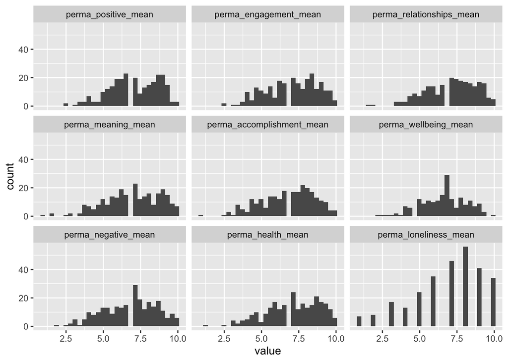

```r
g <- ggplot(df_m,aes(x=value))
g <- g + geom_histogram()
g <- g + facet_wrap(~variable)
g
```

Create a matrix of scatter plots:

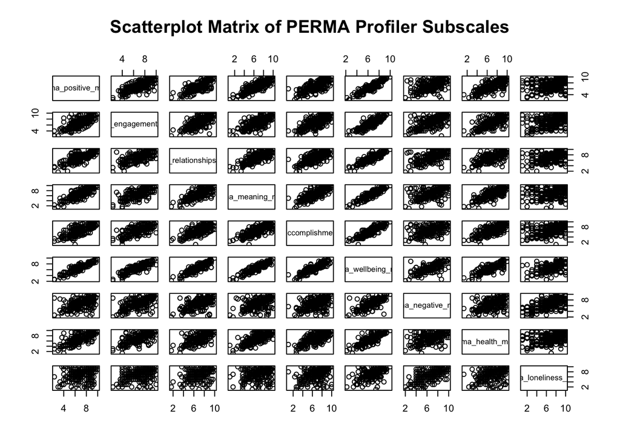

```r
pairs(~perma_positive_mean + perma_engagement_mean + perma_relationships_mean + perma_meaning_mean + perma_accomplishment_mean + perma_wellbeing_mean + perma_negative_mean + perma_health_mean + perma_loneliness_mean, data=df, main="Scatterplot Matrix of PERMA Profiler Subscales")
```

Compute a correlation matrix and then visualize it, using steps from [this site](http://www.sthda.com/english/wiki/ggcorrplot-visualization-of-a-correlation-matrix-using-ggplot2).

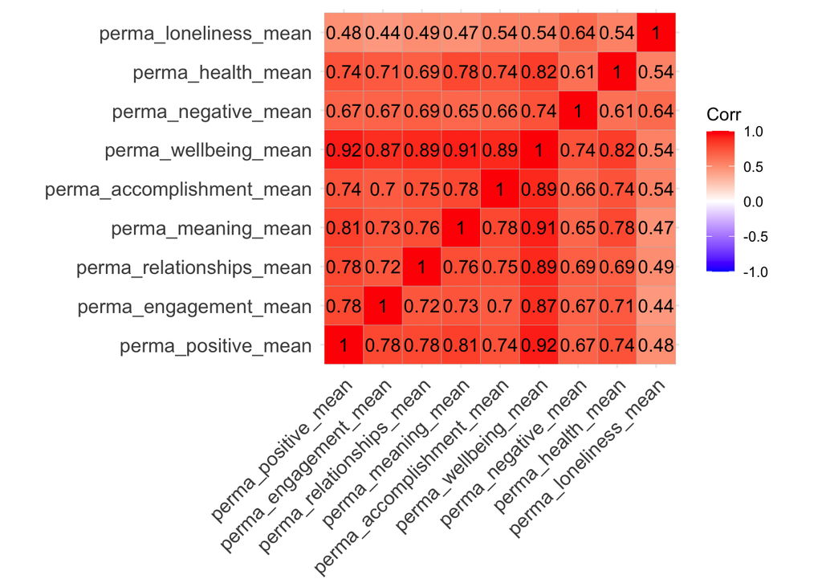

```r
res <-cor(df, use = "complete.obs")
ggcorrplot(res, lab = TRUE)
```